# Analyzing Hospital Length of Stay: A Registry-Based Study

A Negative Binomial Regression Approach to Address Data Overdispersion

Abderrezzaq KADOUCHE

# **Introduction**

The optimization of healthcare delivery requires a deep understanding of inpatient resource utilization, where the length of stay serves as a primary metric for operational efficiency and hospital performance.

Analyzing this metric helps healthcare administrators balance bed occupancy, predict clinical costs, and evaluate the quality of patient management.

# **Objective**

The primary objective of this study is to identify and quantify the clinical, demographic, and institutional determinants of the length of hospital stay for Medicare patients. Specifically, this analysis aims to:

- Determine if Health Maintenance Organization membership alters hospitalization duration.
- Analyze the influence of patient age and racial identification on stay lengths.
- Quantify how elective, urgent, and emergency admissions impact inpatient care duration.

# **Study Design and Data**

This study employs a retrospective, cross-sectional design using data extracted from the 1991 US national Medicare inpatient hospital database. The national dataset compiles hospital filing records annually to monitor healthcare utilization across the United States. The analysis is restricted to the state of Arizona and focuses exclusively on a single diagnostic group: Diagnostic Related Group 112 (DRG 112), which corresponds to Percutaneous Cardiovascular Procedures.

The final sample consists of 1495 unique patient observations randomly selected from the original database. Because a hospital stay must last at least one day to be recorded in this dataset, zero counts are structurally excluded from the study design.

# **Variable Specifications**

- `los`: Length of hospital stay in days. This is the dependent (response) variable, representing discrete count data that is structurally restricted to values greater than or equal to 1.
- `hmo`: Patient managed care status. A binary indicator where 1 denotes membership in a Health Maintenance Organization and 0 denotes traditional fee-for-service coverage.
- `white`: Patient racial identification. A binary indicator where 1 indicates the patient identifies as Caucasian and 0 indicates otherwise.
- `died`: In-hospital clinical outcome. A binary indicator where 1 signifies that the patient died during the hospitalization event and 0 signifies survival to discharge.
- `age80`: Patient age threshold indicator. A binary predictor where 1 represents patients aged 80 years and over, and 0 represents patients under 80.
- `type`: Admission pathway. A categorical variable operationalized through three distinct binary indicators: type1 (Elective admission), type2 (Urgent admission), and type3 (Emergency admission).
- `provnum`: Institutional identifier. A categorical variable recording the unique provider identification number of the specific hospital facility delivering care.

## **CDISC Alignment**

| SDTM Domain | Source Variable | SDTM Variable | ADaM Variable |
| --- | --- | --- | --- |
| **DM** (Demographics) | provnum | DM.SITEID | ADSL.SITEID |
|  | white | DM.RACE | ADSL.RACE |
|  | age80 | DM.AGE | ADSL.AGEGR1 |
|  | hmo | DM.ARM | ADSL.TRT01P |
| **HO** (Healthcare Encounters) | type | HO.HOTYPE | ADHO.HOTYPE |
|  | los | HO.HOSTDTC / HO.HOENDTC | ADHO.AVAL |
| **DS** (Disposition) | died | DS.DSDECOD | ADSL.DTHFL / ADSL.EOSSTT |

## **Descriptive Analysis of Continuous Variables**

```r
library(prettyR)

data <- as.data.frame(medpar)

data$los <- as.numeric(data$los)

vars_quanti <- c("los")


# Création de la fonction personnalisée
extended_summary <- function(x) {
  base_summary <- summary(x)
  extra_stats <- c(Variance = var(x, na.rm = TRUE), `Std.Dev` = sd(x, na.rm = TRUE))
  return(c(base_summary, extra_stats))
}


cat("Length of hospital stay : ")
```

```
## Length of hospital stay :
```

```r
round(extended_summary(medpar$los), 2)
```

```
##     Min.  1st Qu.   Median     Mean  3rd Qu.     Max. Variance  Std.Dev
##     1.00     4.00     8.00     9.85    13.00   116.00    78.02     8.83
```

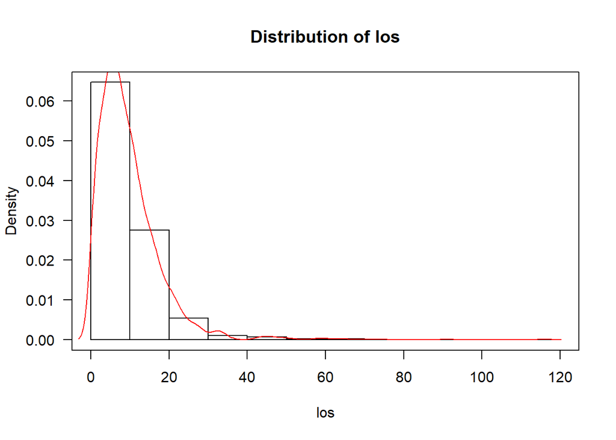

```r
# Boucle sur toutes les variables quantitatives avec courbe de densité

for (var in vars_quanti) {
# 1. Tracer l'histogramme en mode "densité de probabilité" (prob = TRUE)
hist(medpar[[var]],
main = paste("Distribution of", var), # Titre dynamique
xlab = var,                           # Nom de la variable sur l'axe X
ylab = "Density",                     # L'axe Y devient la Densité
las  = 1,  # Labels horizontaux
col  = "white",                       # Barres blanches
border = "black",                     # Contours noirs
prob = TRUE)                          # OBLIGATOIRE pour la densité
# 2. Calculer et superposer la courbe de densité
# na.rm = TRUE est crucial car il peut y avoir des NA dans la colonne 'nodes'
lines(density(medpar[[var]], na.rm = TRUE),
col = "red",                         # Courbe en rouge pour le contraste
lwd = 1)                             # Épaisseur de la ligne
# 3. AJOUT DU CADRE AUTOUR DU GRAPHIQUE

box(col = "black", lwd = 1)
}
```

## **Descriptive analysis of categorical variables**

```r
library(gtsummary)
library(dplyr)

# Étape de nettoyage et recodage des niveaux (noms des modalités)
medpar_clean <- medpar %>%
  mutate(across(everything(), ~ as.numeric(as.character(.)))) %>%
  mutate(
    white = factor(white, levels = c(0, 1), labels = c("Other", "Caucasian")),
    died  = factor(died,  levels = c(0, 1), labels = c("Survived", "Died")),
    age80 = factor(age80, levels = c(0, 1), labels = c("Under 80", "80 and over")),
    type  = factor(type,  levels = c(1, 2, 3), labels = c("Elective", "Urgent", "Emergency")),
    hmo = factor(hmo, levels=c(0, 1), labels=c("Fee-for-Service", "HMO Member"))
  )

# Génération du tableau avec les nouveaux labels de variables
medpar_clean %>%
  select(hmo, white, died, age80, type) %>%
  tbl_summary(
    by = died,
    label = list(
      hmo ~ "Health Maintenance Organization",
      white ~ "Racial Identification",
      age80 ~ "Age Group",
      type  ~ "Admission Pathway Type"
    ),
    statistic = list(
      all_categorical() ~ "{n} ({p}%)"
    ),
    digits = list(
      all_categorical() ~ c(0, 1)
    ),
    missing_text = "Missing"
  ) %>%
  bold_labels()
```

| **Characteristic** | **Survived** N = 982<sup>1</sup> | **Died** N = 513<sup>1</sup> |
| --- | --- | --- |
| Health Maintenance Organization |  |  |
| Fee-for-Service | 825 (84.0%) | 431 (84.0%) |
| HMO Member | 157 (16.0%) | 82 (16.0%) |
| Racial Identification |  |  |
| Other | 91 (9.3%) | 36 (7.0%) |
| Caucasian | 891 (90.7%) | 477 (93.0%) |
| Age Group |  |  |
| Under 80 | 804 (81.9%) | 361 (70.4%) |
| 80 and over | 178 (18.1%) | 152 (29.6%) |
| Admission Pathway Type |  |  |
| Elective | 770 (78.4%) | 364 (71.0%) |
| Urgent | 161 (16.4%) | 104 (20.3%) |
| Emergency | 51 (5.2%) | 45 (8.8%) |

<sup>1</sup> n (%)

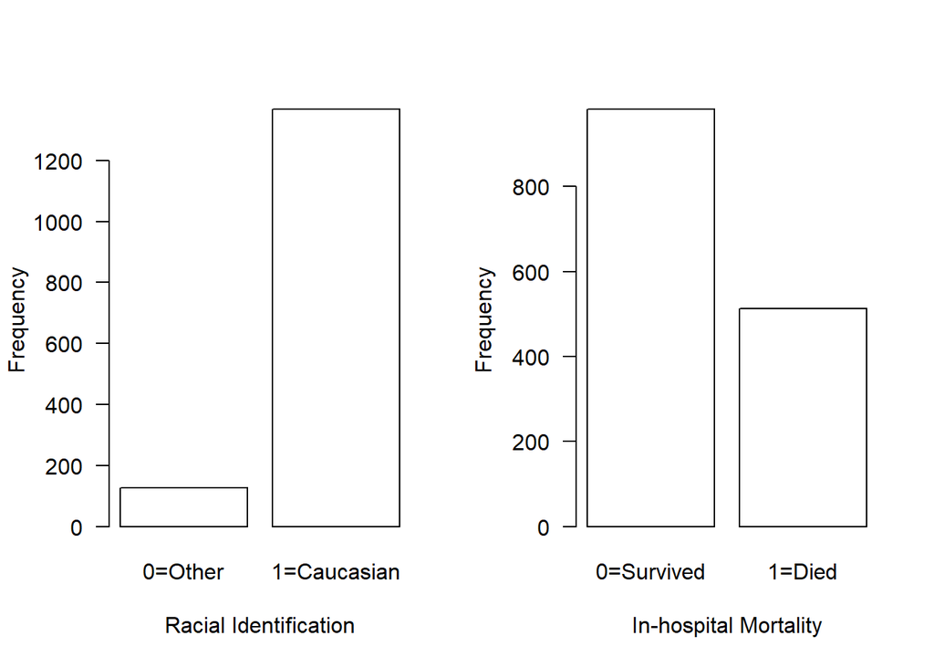

```r
par(mfrow = c(1, 2))

# ── 1. WHITE (Racial identification) ───────────────────
barplot(
  table(medpar$white),
  ylab      = "Frequency",
  xlab      = "Racial Identification",
  names.arg = c("0=Other", "1=Caucasian"),
  col       = "white",
  border    = "black",
  las       = 1,
  cex.names = 1.0,
  cex.lab   = 1.0
)

# ── 2. DIED (In-hospital mortality) ───────────────────
barplot(
  table(medpar$died),
  ylab      = "Frequency",
  xlab      = "In-hospital Mortality",
  names.arg = c("0=Survived", "1=Died"),
  col       = "white",
  border    = "black",
  las       = 1,
  cex.names = 1.0,
  cex.lab   = 1.0
)
```

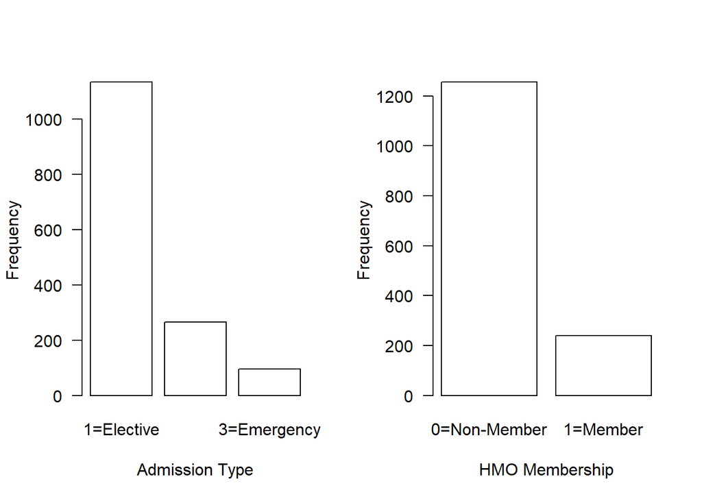

```r
# ── 3. TYPE (Type of admission) ───────────────────────
barplot(
  table(medpar$type),
  ylab      = "Frequency",
  xlab      = "Admission Type",
  names.arg = c("1=Elective", "2=Urgent", "3=Emergency"),
  col       = "white",
  border    = "black",
  las       = 1,
  cex.names = 1.0,
  cex.lab   = 1.0
)

# ── 4. HMO (Health Maintenance Organization) ───────────
barplot(
  table(medpar$hmo),
  ylab      = "Frequency",
  xlab      = "HMO Membership",
  names.arg = c("0=Non-Member", "1=Member"),
  col       = "white",
  border    = "black",
  las       = 1,
  cex.names = 1.0,
  cex.lab   = 1.0
)
```

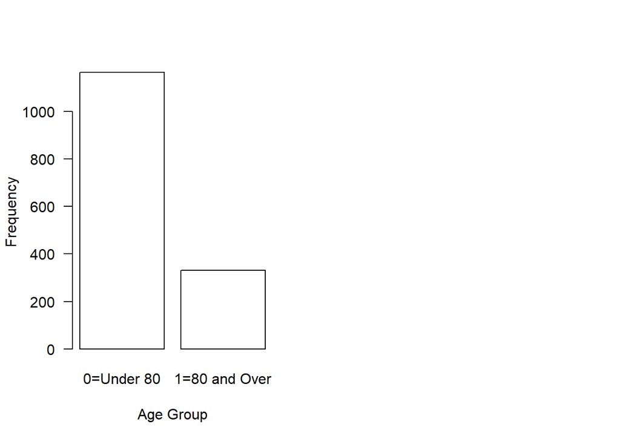

```r
# ── 5. AGE80 (Age Threshold) ───────────────────────────
barplot(
  table(medpar$age80),
  ylab      = "Frequency",
  xlab      = "Age Group",
  names.arg = c("0=Under 80", "1=80 and Over"),
  col       = "white",
  border    = "black",
  las       = 1,
  cex.names = 1.0,
  cex.lab   = 1.0
)
```

## **Missing data**

As shown in the diagnostic output, there are zero missing values (0% NA) across all 10 tracked variables.

```r
tab_NA <- data.frame(
  Variables = names(medpar),
  n_NA = colSums(is.na(medpar)),
  percent_NA = round(colMeans(is.na(medpar)) * 100, 2),
  row.names = NULL
)

print(tab_NA)
```

```
##    Variables n_NA percent_NA
## 1        los    0          0
## 2        hmo    0          0
## 3      white    0          0
## 4       died    0          0
## 5      age80    0          0
## 6       type    0          0
## 7      type1    0          0
## 8      type2    0          0
## 9      type3    0          0
## 10   provnum    0          0
```

## **Statistical Modeling and Diagnostics**

The statistical analysis of the length of hospital stay `los` was conducted using a Negative Binomial regression framework to account for overdispersion within the count data. The model yields Incident Rate Ratios, which quantify the multiplicative effect of each predictor on the expected duration of hospitalization, holding all other variables constant.

```r
#Surdispersion ou non ?

round (mean(medpar$los), 2) #moyenne
```

```
## [1] 9.85
```

```r
round (var (medpar$los), 2) #variance
```

```
## [1] 78.02
```

```r
round (var (medpar$los) / mean(medpar$los), 2) #ratio variance/moyenne
```

```
## [1] 7.92
```

```r
ifelse(var (medpar$los) > mean(medpar$los), "overdispersed" , "Not overdispersed" )
```

```
## [1] "overdispersed"
```

```r
library(MASS) #pour la fonction glm.nb

# Estimation du modèle Binomial Négatif
mod_nb <- glm.nb(
  los ~ died + hmo + white + age80 + factor(type),
  data = medpar
)
```

# **Results**

- The mode of admission stands out as the most powerful determinant of inpatient duration.

Compared to elective admissions (the reference group), urgent admissions increase the expected length of stay by 27.3% (IRR = 1.273).

Strikingly, emergency admissions more than double the expected hospitalization period, leading to a 107.0% increase in stay duration (IRR = 2.070). This underscores how acute, unplanned clinical presentation severely intensifies hospital resource utilization.

```r
summary (mod_nb)
```

```
##
## Call:
## glm.nb(formula = los ~ died + hmo + white + age80 + factor(type),
##     data = medpar, init.theta = 2.304388954, link = log)
##
## Coefficients:
##               Estimate Std. Error z value Pr(>|z|)
## (Intercept)    2.37603    0.06772  35.086  < 2e-16 ***
## died          -0.23350    0.04088  -5.711 1.12e-08 ***
## hmo           -0.06696    0.05276  -1.269   0.2044
## white         -0.12166    0.06772  -1.796   0.0724 .
## age80         -0.01609    0.04650  -0.346   0.7293
## factor(type)2  0.24122    0.05005   4.819 1.44e-06 ***
## factor(type)3  0.72748    0.07553   9.632  < 2e-16 ***
## ---
## Signif. codes:  0 '***' 0.001 '**' 0.01 '*' 0.05 '.' 0.1 ' ' 1
##
## (Dispersion parameter for Negative Binomial(2.3044) family taken to be 1)
##
##     Null deviance: 1726.0  on 1494  degrees of freedom
## Residual deviance: 1566.8  on 1488  degrees of freedom
## AIC: 9577.8
##
## Number of Fisher Scoring iterations: 1
##
##
##               Theta:  2.304
##           Std. Err.:  0.103
##
##  2 x log-likelihood:  -9561.790
```

```r
# Extraction et conversion des coefficients en IRR
round(exp(coef(mod_nb)), 3)
```

```
##   (Intercept)          died           hmo         white         age80
##        10.762         0.792         0.935         0.885         0.984
## factor(type)2 factor(type)3
##         1.273         2.070
```

```r
#Incident Rate Ratios
#IRR > 1 indique une augmentation de la durée de séjour.
#IRR < 1 indique une diminution de la durée de séjour.
```

# **Conclusion**

This study quantified the institutional, clinical, and demographic drivers of hospital length of stay for Medicare patients.

The most critical finding is that hospital stay duration is overwhelmingly dictated by the admission pathway.

Unplanned emergency admissions more than double the expected length of stay (IRR = 2.070), representing the single largest operational burden on hospital capacity. This highlighting how clinical acuity at presentation disrupts standard care timelines.

Ultimately, this analysis underscores how advanced count data modeling can transform administrative billing records into actionable insights for capacity planning and hospital efficiency optimization.